# Caratteristiche del database

# Posizione delle stragi nel terzo intervallo con numero massimo di eventi (1945-04-24 1945-05-04)

```python
#a = df[df['data_inizio'] > datetime.date(1943, 9, 9)and df['data_inizio'] < datetime.date(1943, 11, 13)]
#date_before = datetime.date(2016, 1, 19)
df_inf2 = df[df['data_inizio'] > datetime.date(1945, 4, 24)]
df_compl2 = df_inf2[df_inf2['data_inizio'] < datetime.date(1945, 5, 4)]
df_compl2.head()
```

|  | data_inizio | latitudine | longitudine |
| --- | --- | --- | --- |
| 5408 | 1945-04-25 | 45.598340 | 8.914248 |
| 5409 | 1945-04-25 | 45.095956 | 11.495434 |
| 5410 | 1945-04-25 | 44.868680 | 10.363517 |
| 5411 | 1945-04-25 | 44.980317 | 10.167258 |
| 5412 | 1945-04-25 | 45.334055 | 11.376878 |

```python
df_compl2.dtypes
```

```
data_inizio     object
latitudine     float64
longitudine    float64
dtype: object
```

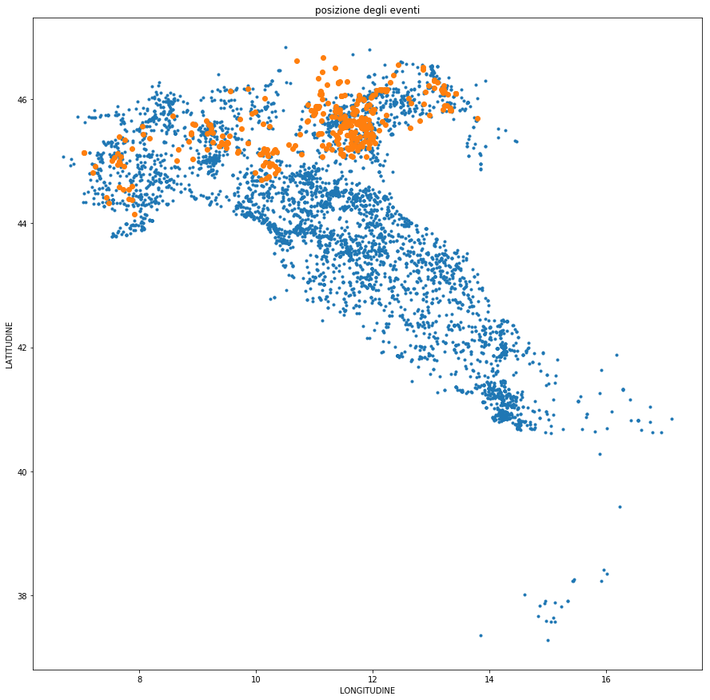

```python
%matplotlib inline
import matplotlib.pyplot as plt

# creazione canvas (le misure sono in pollici))
plt.figure(figsize=(15, 15))

plt.title('posizione degli eventi')    # Titolo del grafico
plt.xlabel('LONGITUDINE')        # Nomi degli assi
plt.ylabel('LATITUDINE')

plt.plot(df.longitudine,df.latitudine, linewidth=0 ,marker=".")
plt.plot(df_compl2.longitudine,df_compl2.latitudine, linewidth=0 ,marker="o")
```

# Stragi compiute dalla XMAS

```python
import MySQLdb
import datetime
import pandas as pd

# Open database connection
db = MySQLdb.connect("localhost","root","paperino","database_stragi" )

# prepare a cursor object using cursor() method
cursor = db.cursor()

#https://www.w3schools.com/sql/sql_join_left.asp
#La parola chiave LEFT JOIN restituisce tutti i record dalla tabella di sinistra (Clienti),
#anche se non ci sono corrispondenze nella tabella di destra (Ordini).
# se al posto del LEFT JOIN uso il JOIN, spariscono tutte le stragi che hanno alcune colonne 'repartoresponsabilei'
# con valori nulli

sql = '''
SELECT ST.datainizio, ST.id_strage,CO.lat, CO.lng, REP1.reparto AS reparto1  , REP2.reparto AS reparto2,
REP3.reparto AS reparto3, REP4.reparto AS reparto4, REP5.reparto AS reparto5, REP6.reparto AS reparto6,
REP7.reparto AS reparto7
FROM dba__stragi AS ST JOIN dba__coordinate AS CO
ON ST.id_strage=CO.id_strage
LEFT JOIN dba__reparti AS REP1
ON ST.repartoresponsabile1=REP1.id_reparto
LEFT JOIN dba__reparti AS REP2
ON ST.repartoresponsabile2=REP2.id_reparto
LEFT JOIN dba__reparti AS REP3
ON ST.repartoresponsabile3=REP3.id_reparto
LEFT JOIN dba__reparti AS REP4
ON ST.repartoresponsabile4=REP4.id_reparto
LEFT JOIN dba__reparti AS REP5
ON ST.repartoresponsabile5=REP5.id_reparto
LEFT JOIN dba__reparti AS REP6
ON ST.repartoresponsabile6=REP6.id_reparto
LEFT JOIN dba__reparti AS REP7
ON ST.repartoresponsabile7=REP7.id_reparto
ORDER BY ST.datainizio
'''
cursor.execute(sql)
results = cursor.fetchall()

lista=list(results)

df6 = pd.DataFrame(lista,columns=[i[0] for i in cursor.description])
df6.head()
```

|  | datainizio | id_strage | lat | lng | reparto1 | reparto2 | reparto3 | reparto4 | reparto5 | reparto6 | reparto7 |
| --- | --- | --- | --- | --- | --- | --- | --- | --- | --- | --- | --- |
| 0 | None | 1196 | 41.2993991 | 15.0852503 | Fallschirm-Jäger-Regiment 3/Kampfgruppe Heilma... | None | None | None | None | None | None |
| 1 | None | 5391 | 43.8958773 | 10.3175155 | Reparto tedesco non precisato | None | None | None | None | None | None |
| 2 | None | 1191 | 41.4530456 | 14.2537107 | Panzer-Aufklärungs-Abteilung 103/3. Panzer-Gre... | None | None | None | None | None | None |
| 3 | None | 1260 | 41.2755804 | 14.30229 | II./Panzer-Grenadier-Regiment 8/3. Panzer-Gren... | I./Pz.Gren.Rgt. 29/3. Panzer-Grenadier-Divisio... | None | None | None | None | None |
| 4 | None | 4643 | 44.009278 | 10.1006553 | Reparto tedesco non precisato | None | None | None | None | None | None |

```python
import pandas as pd
lista=[]

for indice, row in df6.iterrows():
    if row['reparto1']=='X MAS'or row['reparto2']=='X MAS'or row['reparto3']=='X MAS'or row['reparto4']=='X MAS' or row['reparto5']=='X MAS'or row['reparto6']=='X MAS'or row['reparto7']=='X MAS':
        lista.append(df6.iloc[indice])
df7=pd.DataFrame(lista)
df7.head()
```

|  | datainizio | id_strage | lat | lng | reparto1 | reparto2 | reparto3 | reparto4 | reparto5 | reparto6 | reparto7 |
| --- | --- | --- | --- | --- | --- | --- | --- | --- | --- | --- | --- |
| 1439 | 1944-04-05 | 1428 | 44.3103426 | 9.7319766 | X MAS | None | None | None | None | None | None |
| 1655 | 1944-05-04 | 4842 | 44.2510963 | 10.1930892 | Pz.Aufkl.Abt./Fallschirm-Panzer-Division Herm... | Festungs-Bataillon 905/FB 135 | Festungs-Bataillon 906/FB 135 | X MAS | Reparto GNR non precisato | Reparto esercito RSI non precisato | None |
| 2077 | 1944-06-15 | 4624 | 44.4296471 | 9.8351635 | X MAS | None | None | None | None | None | None |
| 2168 | 1944-06-18 | 5043 | 45.7307015 | 8.6365972 | 8. Legione Varese | X MAS | None | None | None | None | None |
| 2384 | 1944-06-28 | 1460 | 44.171315 | 9.8540443 | X MAS | None | None | None | None | None | None |

```python
df7.lng=df7.lng.astype(float)
df7.lat=df7.lat.astype(float)
df7.dtypes
```

```
datainizio     object
id_strage       int64
lat           float64
lng           float64
reparto1       object
reparto2       object
reparto3       object
reparto4       object
reparto5       object
reparto6       object
reparto7       object
dtype: object
```

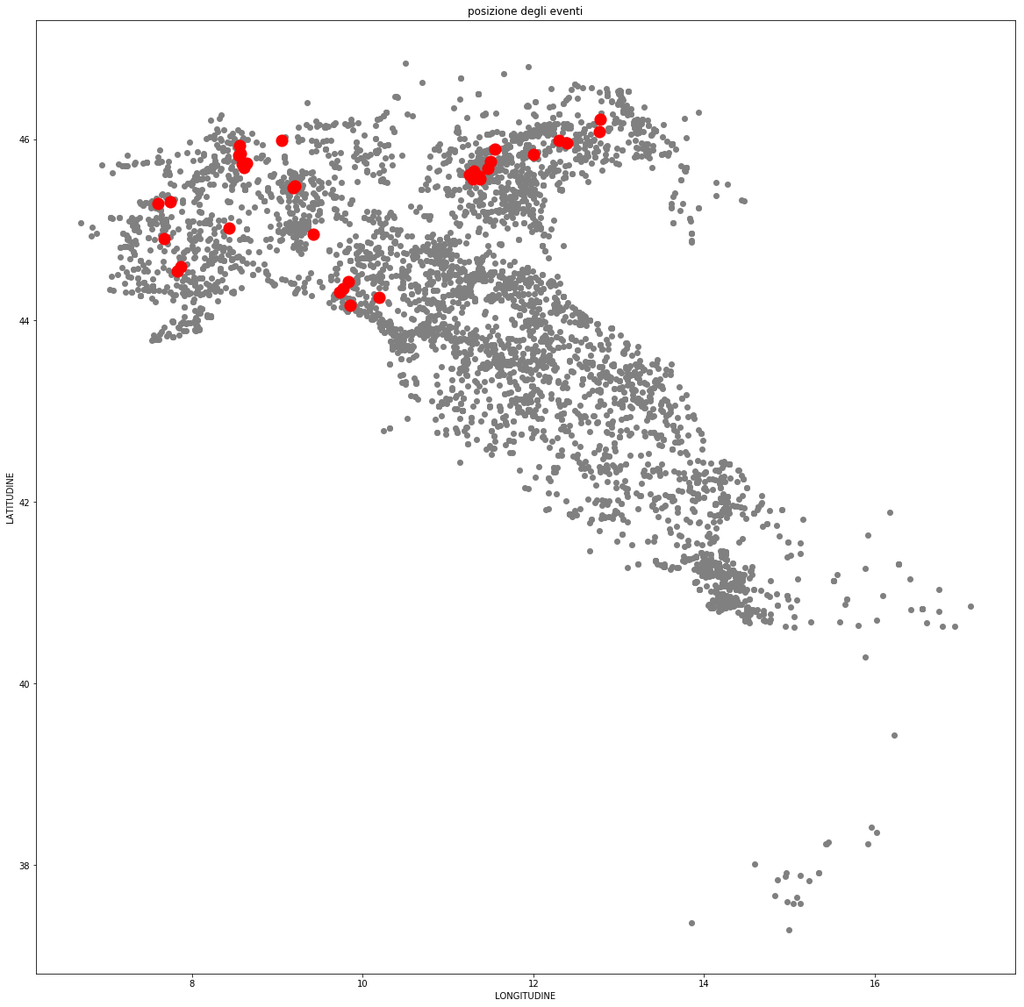

```python
%matplotlib inline
import matplotlib.pyplot as plt

# creazione canvas (le misure sono in pollici))
plt.figure(figsize=(20, 20))

plt.title('posizione degli eventi')    # Titolo del grafico
plt.xlabel('LONGITUDINE')        # Nomi degli assi
plt.ylabel('LATITUDINE')
plt.scatter(df.longitudine, df.latitudine, linewidths=0, marker='.', s=200,c='grey')
#plt.plot(df.longitudine,df.latitudine, linewidth=0 ,marker=".", color="grey")
plt.scatter(df7['lng'], df7['lat'], linewidths=0, marker='o', s=200,c='red')
#plt.plot(df7['lng'],df7['lat'], linewidth=0 ,marker="s", color="r")
```

# Correlazione eventi-vittime

```python
import MySQLdb
import datetime
import pandas as pd

# Open database connection
db = MySQLdb.connect("localhost","root","paperino","database_stragi" )

# prepare a cursor object using cursor() method
cursor = db.cursor()

sql = '''
SELECT datainizio,SUM(vittimetot) AS numero_vittime,COUNT(datainizio) AS eventi
FROM dba__stragi
GROUP BY datainizio
ORDER BY datainizio
'''
cursor.execute(sql)
results = cursor.fetchall()

lista=list(results)
```

```python
df5 = pd.DataFrame(lista,columns=('data_inizio','numero_vittime','numero_eventi'))
```

```python
df5.head()
```

|  | data_inizio | numero_vittime | numero_eventi |
| --- | --- | --- | --- |
| 0 | None | 5 | 0 |
| 1 | None | 191 | 46 |
| 2 | 0001-01-01 | 6 | 4 |
| 3 | None | 1 | 1 |
| 4 | 1943-07-01 | 2 | 1 |

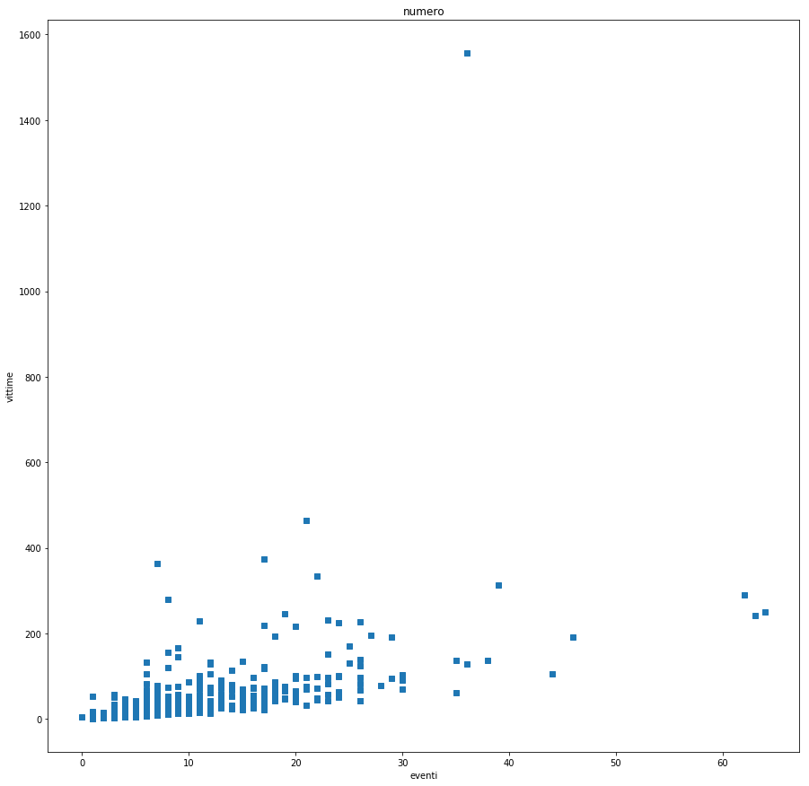

```python
%matplotlib inline
import matplotlib.pyplot as plt

# creazione canvas (le misure sono in pollici))
plt.figure(figsize=(15, 15))

plt.title('numero')    # Titolo del grafico
plt.xlabel('eventi')        # Nomi degli assi
plt.ylabel('vittime')

#plt.plot(df5.numero_eventi,df5.numero_vittime, linewidth=0 ,marker=".")
plt.plot(df5['numero_eventi'],df5['numero_vittime'], linewidth=0 ,marker="s")
```

# Cluster posizione data

```python
import MySQLdb
import datetime
import pandas as pd

# Open database connection
db = MySQLdb.connect("localhost","root","paperino","database_stragi" )

# prepare a cursor object using cursor() method
cursor = db.cursor()

sql = '''
SELECT ST.datainizio, CO.lat, CO.lng
FROM dba__stragi AS ST JOIN dba__coordinate AS CO ON ST.id_strage=CO.id_strage
ORDER BY ST.datainizio
'''

cursor.execute(sql)
results = cursor.fetchall()

lista=list(results)

df = pd.DataFrame(lista,columns=('data_inizio','latitudine','longitudine'))
```

```python
for indice,riga in df.iterrows():
    if riga.data_inizio==None:
        df=df.drop([indice]) # tolgo la riga e aggiorno il dataframe
    if riga.data_inizio==datetime.date(1, 1, 1):
        df=df.drop([indice]) # tolgo la riga e aggiorno il dataframe
    if riga.latitudine=="43.353583,":
        df=df.drop([indice])
```

```python
print(df.dtypes)
print(df['data_inizio'].dtypes)
```

```
data_inizio    object
latitudine     object
longitudine    object
dtype: object
object
```

```python
# trasformo la stringa "1943-7-1" in un oggetto date
from datetime import date
anno,mese,giorno = "1943-7-1".split("-")
d = date(int(anno), int(mese), int(giorno))
d
```

```
datetime.date(1943, 7, 1)
```

```python
import pandas as pd
from datetime import date

# trasformo la stringa "1943-7-1" in un oggetto date
anno,mese,giorno = "1943-7-1".split("-")
d = date(int(anno), int(mese), int(giorno))

# creo la colonna 'data_modif' che contiene il timedelta
# tra una generica data  e la data d="1943-7-1"
df['data_modif']=df['data_inizio']-d
#df=df.drop('data_inizio',axis=1)
df.tail()
#dtype(df)
```

|  | data_inizio | latitudine | longitudine | data_modif |
| --- | --- | --- | --- | --- |
| 5745 | 1945-05-04 | 46.0166432 | 11.8007798 | 673 days |
| 5746 | 1945-05-05 | 46.3491942 | 13.0671185 | 674 days |
| 5747 | 1945-05-06 | 46.1069336 | 11.1120652 | 675 days |
| 5748 | 1945-05-08 | 45.1596663 | 9.313989 | 677 days |
| 5749 | 1945-05-14 | 45.4789961 | 8.4616152 | 683 days |

```python
### trasformo gli oggetti timedelta
# negli interi giorni
contatore=0
for td in df['data_modif']:
    if contatore<=5:
        contatore=contatore+1
        #trasformo timedelta (11 days) in un intero
        print(type(td.days),'   ',td.days)
```

```
<class 'int'>     0
<class 'int'>     11
<class 'int'>     16
<class 'int'>     31
<class 'int'>     31
<class 'int'>     33
```

```python
# creo una lista vuota
l=[]
# trasformo gli oggetti timedelta
# negli oggetti interi giorni
for td in df['data_modif']:
    l.append(td.days)
df['data_modif']=l
df.head()
```

|  | data_inizio | latitudine | longitudine | data_modif |
| --- | --- | --- | --- | --- |
| 55 | 1943-07-01 | 37.2838188 | 14.996114 | 0 |
| 56 | 1943-07-12 | 37.3581785 | 13.8506902 | 11 |
| 57 | 1943-07-17 | 37.5898196 | 14.9768276 | 16 |
| 58 | 1943-08-01 | 37.9171826 | 14.9634651 | 31 |
| 59 | 1943-08-01 | 37.8778815 | 14.9507373 | 31 |

```python
print(df.dtypes)
```

```
data_inizio    object
latitudine     object
longitudine    object
data_modif      int64
dtype: object
```

```python
df.longitudine=df.longitudine.astype(float)
df.latitudine=df.latitudine.astype(float)
```

```python
print(df.dtypes)
```

```
data_inizio     object
latitudine     float64
longitudine    float64
data_modif       int64
dtype: object
```

```python
df.head()
```

|  | data_inizio | latitudine | longitudine | data_modif |
| --- | --- | --- | --- | --- |
| 55 | 1943-07-01 | 37.283819 | 14.996114 | 0 |
| 56 | 1943-07-12 | 37.358179 | 13.850690 | 11 |
| 57 | 1943-07-17 | 37.589820 | 14.976828 | 16 |
| 58 | 1943-08-01 | 37.917183 | 14.963465 | 31 |
| 59 | 1943-08-01 | 37.877882 | 14.950737 | 31 |

#### PROBLEMA

Ho problemi a trovare i cluster tra data, latitud e longit perchè abbiamo a che fare con dati aventi scale diverse:

il valore dei giorni varia tra 0 e 683 mentre lat e longit variano in una finestra ("valore_massimo" , "valore_minimo") di valori interi.

#### SOLUZIONE

devo normalizzare i dati su cui calcolo i cluster.

normalizzo il valore dei giorni: divido tutti i valori per il valore massimo

normalizzo lat e longit rispetto alla finestra di valori "valore_massimo" e "valore_minimo" :

sottraggo ad ogni valore ,"valore_minimo" quindi divido il risultato per ( "valore_massimo" - "valore_minimo" )

```python
# normalizzo i giorni rispetto il loro valore massimo
df['data_modif']=df['data_modif']/df['data_modif'].max()

# normalizzo la longitudine rispetto la sua finestra
longitudine_Max=df.longitudine.max()
longitudine_min=df.longitudine.min()
df['longitudine_norm']=(df['longitudine']-longitudine_min)/(longitudine_Max-longitudine_min)

# normalizzo la latitudine rispetto la sua finestra
latitudine_Max=df.latitudine.max()
latitudine_min=df.latitudine.min()
df['latitudine_norm']=(df['latitudine']-latitudine_min)/(latitudine_Max-latitudine_min)
df.head()
```

|  | data_inizio | latitudine | longitudine | data_modif | longitudine_norm | latitudine_norm |
| --- | --- | --- | --- | --- | --- | --- |
| 55 | 1943-07-01 | 37.283819 | 14.996114 | 0.000000 | 0.796218 | 0.000000 |
| 56 | 1943-07-12 | 37.358179 | 13.850690 | 0.016105 | 0.686339 | 0.007787 |
| 57 | 1943-07-17 | 37.589820 | 14.976828 | 0.023426 | 0.794368 | 0.032044 |
| 58 | 1943-08-01 | 37.917183 | 14.963465 | 0.045388 | 0.793086 | 0.066324 |
| 59 | 1943-08-01 | 37.877882 | 14.950737 | 0.045388 | 0.791865 | 0.062209 |

```python
colonne_da_selezionare=['data_modif','longitudine_norm','latitudine_norm']
X=df[colonne_da_selezionare]
```

```python
# K-means con 6 cluster
from sklearn.cluster import KMeans
km = KMeans(n_clusters=6, random_state=1)
km.fit(X)
```

```
KMeans(algorithm='auto', copy_x=True, init='k-means++', max_iter=300,
    n_clusters=6, n_init=10, n_jobs=1, precompute_distances='auto',
    random_state=1, tol=0.0001, verbose=0)
```

```
Text(0,0.5,'longitudine')
```

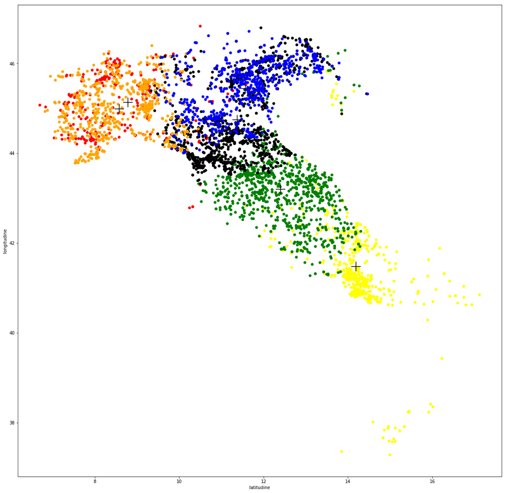

```python
import matplotlib.pyplot as plt
import numpy as np
%matplotlib inline

# creazione canvas (le misure sono in pollici))
plt.figure(figsize=(20, 20))

# salva il DataFrame dei centri dei cluster
df['cluster']=km.labels_
centers = df.groupby('cluster').mean()

# crea un array colors per il grafico
colors = np.array(['red', 'green', 'blue', 'yellow', 'black', 'orange'])

# grafico a dispersione
# colorato per cluster (0=rosso, 1=verde, 2=blu)
plt.scatter(df.longitudine, df.latitudine, c=colors[list(df.cluster)], s=30)

# centri dei cluster, indicati con "+"
plt.scatter(centers.longitudine, centers.latitudine, linewidths=100, marker='+', s=500,c='black')

# aggiunge le etichette
plt.xlabel('latitudine')
plt.ylabel('longitudine')
```

```python
df.head()
```

|  | data_inizio | latitudine | longitudine | data_modif | longitudine_norm | latitudine_norm | cluster |
| --- | --- | --- | --- | --- | --- | --- | --- |
| 55 | 1943-07-01 | 37.283819 | 14.996114 | 0.000000 | 0.796218 | 0.000000 | 3 |
| 56 | 1943-07-12 | 37.358179 | 13.850690 | 0.016105 | 0.686339 | 0.007787 | 3 |
| 57 | 1943-07-17 | 37.589820 | 14.976828 | 0.023426 | 0.794368 | 0.032044 | 3 |
| 58 | 1943-08-01 | 37.917183 | 14.963465 | 0.045388 | 0.793086 | 0.066324 | 3 |
| 59 | 1943-08-01 | 37.877882 | 14.950737 | 0.045388 | 0.791865 | 0.062209 | 3 |

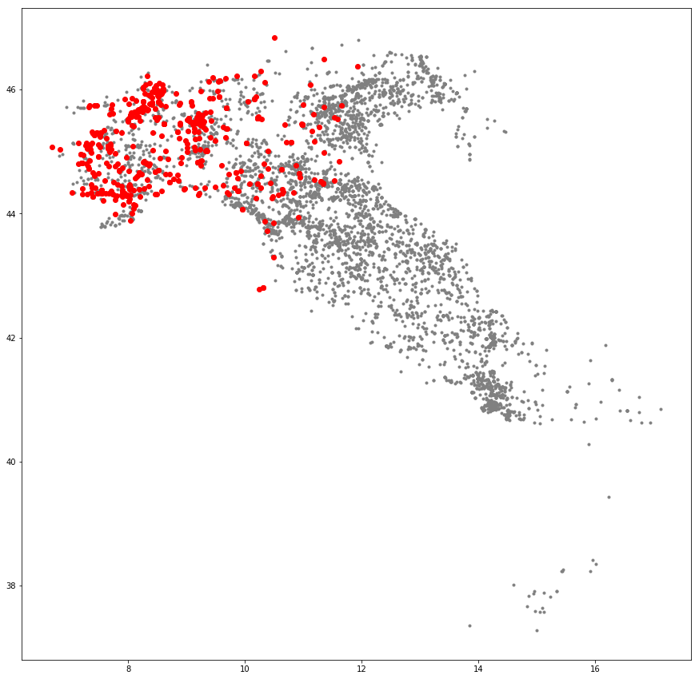

```python
plt.figure(figsize=(15, 15))
df1=df[df['cluster']==0]
plt.plot(df.longitudine,df.latitudine, linewidth=0 ,marker=".", color="grey" )
plt.plot(df1.longitudine, df1.latitudine, c='red',linewidth=0 ,marker="o")
```

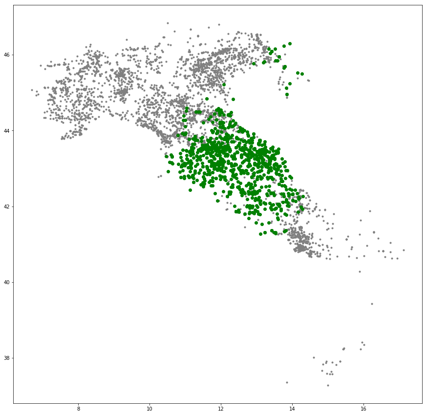

```python
plt.figure(figsize=(15, 15))
df1=df[df['cluster']==1]

plt.plot(df.longitudine,df.latitudine, linewidth=0 ,marker=".", color="grey" )
plt.plot(df1.longitudine, df1.latitudine, c='green',linewidth=0 ,marker="o")
```

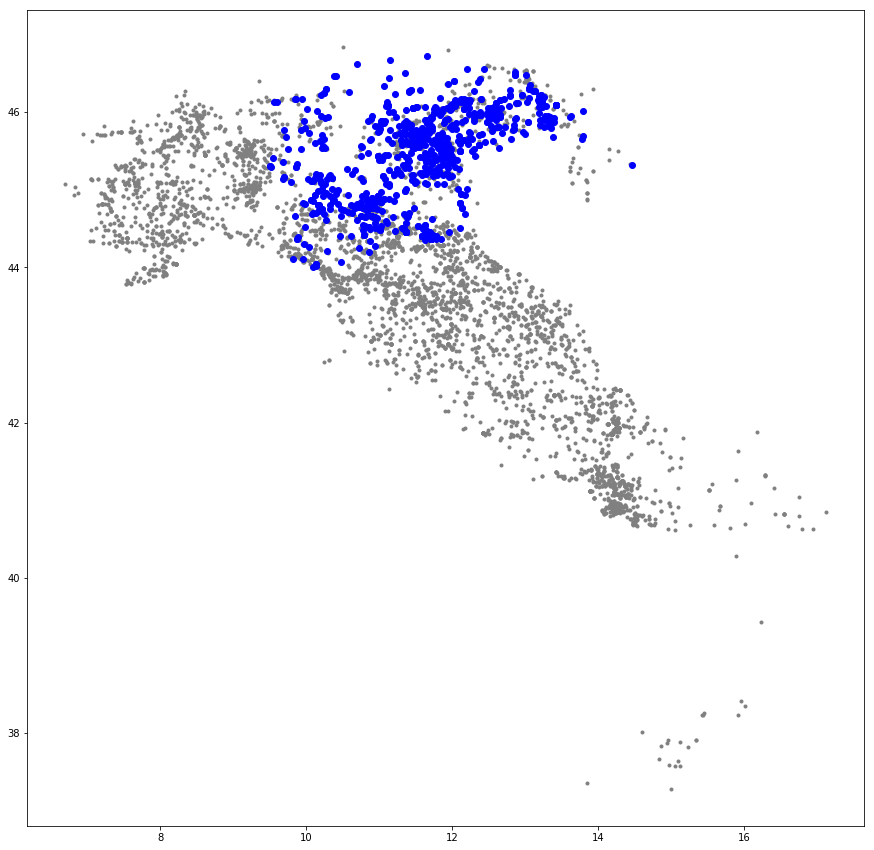

```python
plt.figure(figsize=(15, 15))
df1=df[df['cluster']==2]

plt.plot(df.longitudine,df.latitudine, linewidth=0 ,marker=".", color="grey" )
plt.plot(df1.longitudine, df1.latitudine, c='blue',linewidth=0 ,marker="o")
```

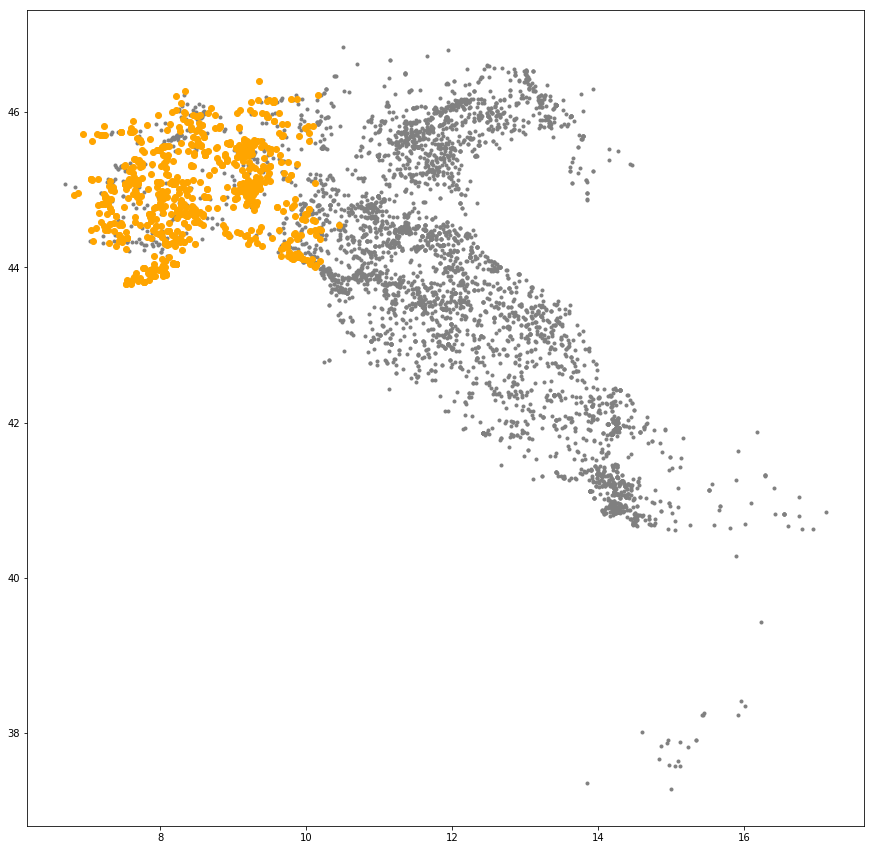

```python
plt.figure(figsize=(15, 15))
df1=df[df['cluster']==5]

plt.plot(df.longitudine,df.latitudine, linewidth=0 ,marker=".", color="grey" )
plt.plot(df1.longitudine, df1.latitudine, c='orange',linewidth=0 ,marker="o")
```

# Cluster posizione,data,vittime

```python
import MySQLdb
import datetime
import pandas as pd

# Open database connection
db = MySQLdb.connect("localhost","root","paperino","database_stragi" )

# prepare a cursor object using cursor() method
cursor = db.cursor()

sql = '''
SELECT ST.datainizio,ST.vittimetot, CO.lat, CO.lng
FROM dba__stragi AS ST JOIN dba__coordinate AS CO ON ST.id_strage=CO.id_strage
ORDER BY ST.datainizio
'''

cursor.execute(sql)
results = cursor.fetchall()

lista=list(results)

df2 = pd.DataFrame(lista,columns=[i[0] for i in cursor.description])
```

```python
for indice,riga in df2.iterrows():
    if riga.datainizio==None:
        df2=df2.drop([indice]) # tolgo la riga e aggiorno il dataframe
    if riga.datainizio==datetime.date(1, 1, 1):
        df2=df2.drop([indice]) # tolgo la riga e aggiorno il dataframe
    if riga.lat=="43.353583,":
        df2=df2.drop([indice])
```

```python
import pandas as pd
from datetime import date

# trasformo la stringa "1943-7-1" in un oggetto date
anno,mese,giorno = "1943-7-1".split("-")
d = date(int(anno), int(mese), int(giorno))

# creo la colonna 'data_modif' che contiene il timedelta
# tra una generica data  e la data d="1943-7-1"
df2['data_modif']=df2['datainizio']-d
#df=df.drop('data_inizio',axis=1)
df2.tail()
#dtype(df)
```

|  | datainizio | vittimetot | lat | lng | data_modif |
| --- | --- | --- | --- | --- | --- |
| 5745 | 1945-05-04 | 7 | 46.0055495 | 11.1935763 | 673 days |
| 5746 | 1945-05-05 | 4 | 46.3491942 | 13.0671185 | 674 days |
| 5747 | 1945-05-06 | 1 | 46.1069336 | 11.1120652 | 675 days |
| 5748 | 1945-05-08 | 2 | 45.1596663 | 9.313989 | 677 days |
| 5749 | 1945-05-14 | 1 | 45.4789961 | 8.4616152 | 683 days |

```python
# creo una lista vuota
l=[]
# trasformo gli oggetti timedelta
# negli oggetti interi giorni
for td in df2['data_modif']:
    l.append(td.days)
df2['data_modif']=l
df2.head()
```

|  | datainizio | vittimetot | lat | lng | data_modif |
| --- | --- | --- | --- | --- | --- |
| 55 | 1943-07-01 | 2 | 37.2838188 | 14.996114 | 0 |
| 56 | 1943-07-12 | 6 | 37.3581785 | 13.8506902 | 11 |
| 57 | 1943-07-17 | 1 | 37.5898196 | 14.9768276 | 16 |
| 58 | 1943-08-01 | 1 | 37.9171826 | 14.9634651 | 31 |
| 59 | 1943-08-01 | 3 | 37.8778815 | 14.9507373 | 31 |

```python
df2.lng=df2.lng.astype(float)
df2.lat=df2.lat.astype(float)
print(df2.dtypes)
```

```
datainizio     object
vittimetot      int64
lat           float64
lng           float64
data_modif      int64
dtype: object
```

```python
# normalizzo i giorni rispetto il loro valore massimo
df2['data_modif']=df2['data_modif']/df2['data_modif'].max()

# normalizzo la longitudine rispetto la sua finestra
lng_Max=df2.lng.max()
lng_min=df2.lng.min()
df2['longitudine_norm']=(df2['lng']-lng_min)/(lng_Max-lng_min)

# normalizzo la latitudine rispetto la sua finestra
lat_Max=df2.lat.max()
lat_min=df2.lat.min()
df2['latitudine_norm']=(df2['lat']-lat_min)/(lat_Max-lat_min)

# normalizzo il numero delle vittime
vittimetot_Max=df2.vittimetot.max()
vittimetot_min=df2.vittimetot.min()
df2['vittimetot_norm']=(df2['vittimetot']-vittimetot_min)/(vittimetot_Max-vittimetot_min)
df2.head()
```

|  | datainizio | vittimetot | lat | lng | data_modif | longitudine_norm | latitudine_norm | vittimetot_norm |
| --- | --- | --- | --- | --- | --- | --- | --- | --- |
| 55 | 1943-07-01 | 2 | 37.283819 | 14.996114 | 0.000000 | 0.796218 | 0.000000 | 0.002597 |
| 56 | 1943-07-12 | 6 | 37.358179 | 13.850690 | 0.016105 | 0.686339 | 0.007787 | 0.007792 |
| 57 | 1943-07-17 | 1 | 37.589820 | 14.976828 | 0.023426 | 0.794368 | 0.032044 | 0.001299 |
| 58 | 1943-08-01 | 1 | 37.917183 | 14.963465 | 0.045388 | 0.793086 | 0.066324 | 0.001299 |
| 59 | 1943-08-01 | 3 | 37.877882 | 14.950737 | 0.045388 | 0.791865 | 0.062209 | 0.003896 |

```python
colonne_da_selezionare=['data_modif','longitudine_norm','latitudine_norm','vittimetot_norm']
X=df2[colonne_da_selezionare]
```

```python
# K-means con 6 cluster
from sklearn.cluster import KMeans
km = KMeans(n_clusters=6, random_state=1)
km.fit(X)
```

```
KMeans(algorithm='auto', copy_x=True, init='k-means++', max_iter=300,
    n_clusters=6, n_init=10, n_jobs=1, precompute_distances='auto',
    random_state=1, tol=0.0001, verbose=0)
```

```
Text(0,0.5,'longitudine')
```

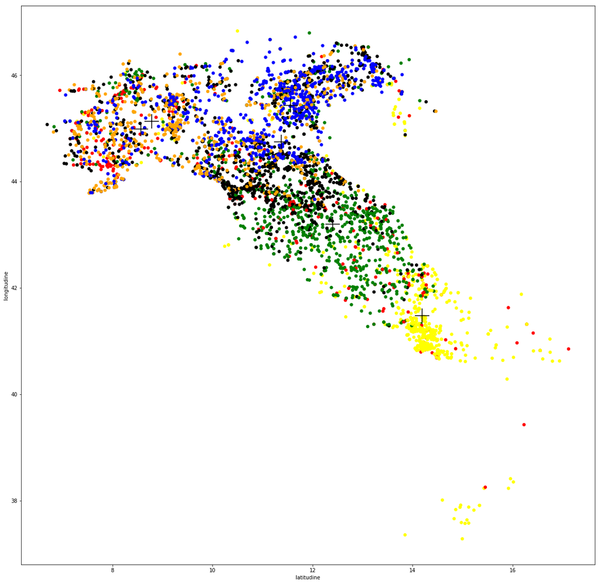

```python
import matplotlib.pyplot as plt
import numpy as np
%matplotlib inline

# creazione canvas (le misure sono in pollici))
plt.figure(figsize=(20, 20))

# salva il DataFrame dei centri dei cluster
df2['cluster']=km.labels_
centers = df2.groupby('cluster').mean()

# crea un array colors per il grafico
colors = np.array(['red', 'green', 'blue', 'yellow', 'black', 'orange'])

# grafico a dispersione delle calorie e dell'alcol,
# colorato per cluster (0=rosso, 1=verde, 2=blu)
plt.scatter(df2.lng, df2.lat, c=colors[list(df.cluster)], s=30)

# centri dei cluster, indicati con "+"
plt.scatter(centers.lng, centers.lat, linewidths=100, marker='+', s=800,c='black')

# aggiunge le etichette
plt.xlabel('latitudine')
plt.ylabel('longitudine')
```